# Low-Back Merger in California English: Working Paper

Christian Brickhouse

March 25, 2019

## Caveat

This draft represents a work in progress and therefore **you should not cite this work for any reason**. The analysis is still ongoing and so this document will change substantially and without notice. Further work may demonstrate significant errors in present or past texts, and so readers should be aware that this analysis is subject to change as more work is done. This document is not intended as a scholarly publication but as living documentation of the ongoing analysis.

## Methods

The wordlists were force aligned using the Penn Forced Aligner (citation), extracted by automated script (see extract_vowels_cj.praat), and analyzed using PraatSauce (citation). Vowels were normalized using the Nearey method (citation) before analysis.

## Results

```
## [1] "Number of participants per fieldsite:"
```

```
##
## BAK HUM MER RDL RED SAC SAL
## 111  96  59  81  97 139  80
```

### Vowel Space Shape

To investigate whether the phonetic movement of the LOT and THOUGHT vowels is causing a shift in the shape of the vowel space, the vowels were treated as vectors and their angles measured. If the vowel space were triangular then the LOT-THOUGHT vowels should lie on the line between the lowest vowel and the highest backest vowel. For each speaker an algorithm identified both the lowest vowel that was not LOT or THOUGHT and the highest backest vowel. The high back vowel was defined as a vowel in the vowel classes of BOAT or POOL that had the lowest Euclidean distance from the origin in Hz space (i.e., closest to the origin).

The high back vowel and the LOT vowel were then converted to vectors from the low front vowel in order to test the hypothesis that LOT lies along the line between the low vowel and high back vowel. If this hypothesis were true then the angle between the two vectors should be zero. The alternative hypothesis—that the vowel space is trapezoidal—would predict that the LOT vector would have an angle of zero with the horizontal (F2) unit vector. As the plot below shows, the LOT vector appears to have minimal overlap with the high back vector, suggesting that there is not a consensus for triangular vowel spaces.

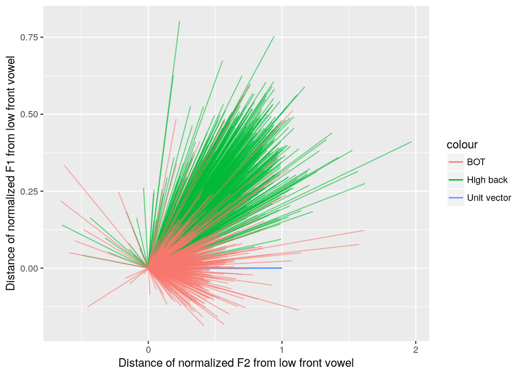

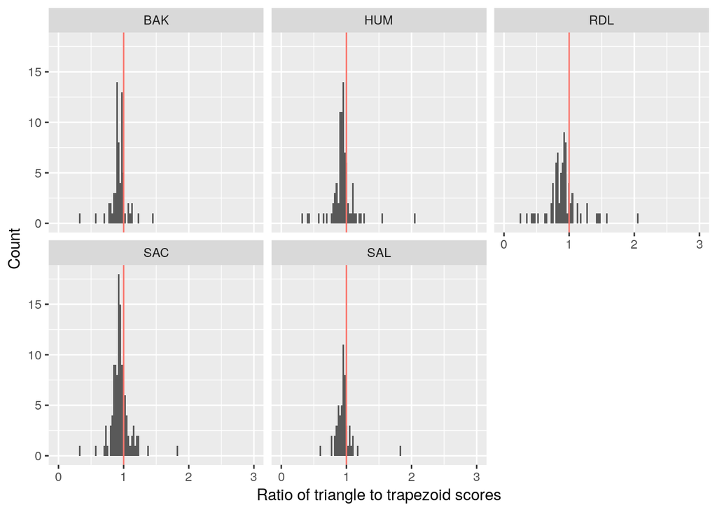

However because the California Vowel Shift seems to be a change in progress, this analysis should consider how the vowel space has been changing over time. The figure below shows the triangle to trapezoid ratio for a participant by their birth year, and there appears to be a trend in apparent time whereby younger participants have a more triangular vowel space. For this analysis the data was further subsetted to remove those whose birthyear was unknown and any participant with negative ratio values as they were few and (from the first figure) likely to be measurement errors. The pattern seems strongest in Bakersfield and Sacramento. Redlands looks to have an increasing trend however younger speakers there seem to have a wider envelope of variation which may indicate an interesting social patterning of the low back vowels.

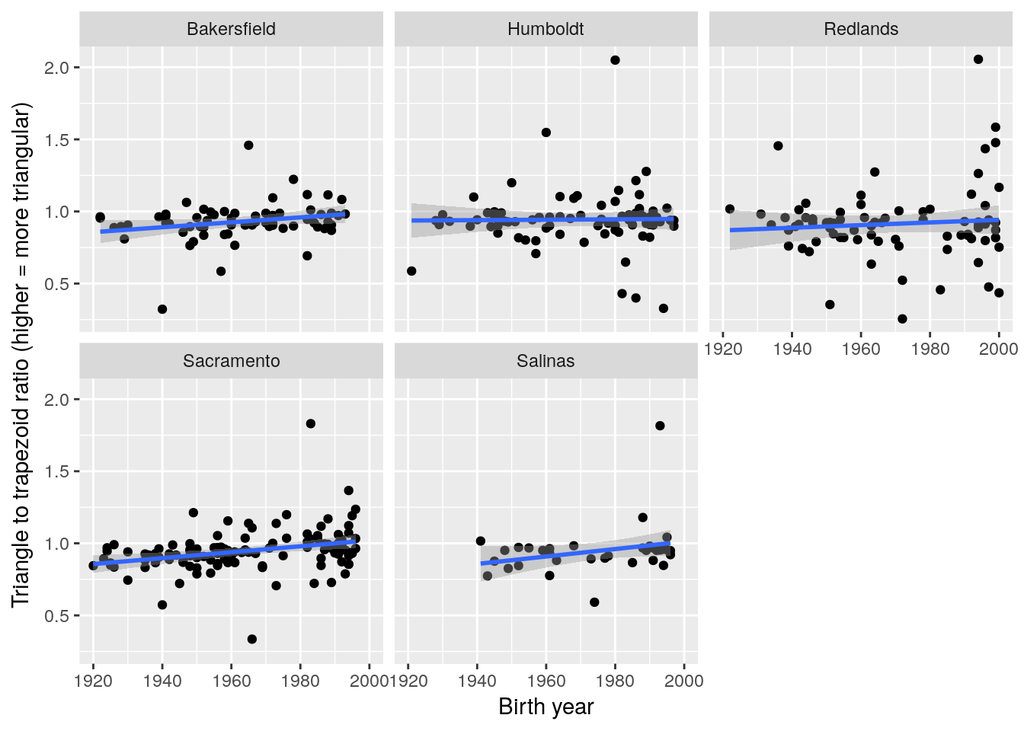